Skip to contents

# Get started with pubflow

Source: [`vignettes/v01-get-started.Rmd`](https://github.com/rpahl/pubflow/blob/main/vignettes/v01-get-started.Rmd)

{pipeflow} computes the results of an analysis in pipeline steps. {pubflow} adds what you need to *publish* these results:

- **parameters** that describe themselves (label, limits, description) and check their values;
- **outputs** for documents: tables, figures and text;
- **documents** that steps of the pipeline build from these outputs;
- **reports** in HTML, Word and PDF format;
- **Shiny modules** for a parameter UI and a document viewer.

This vignette goes through all of them with one small example. It assumes that you know how to build and run a pipeline; if not, read pipeflow’s [Get started](https://cran.r-project.org/package=pipeflow/vignettes/v01-get-started.html) first.

### The example

We use the example of pipeflow’s Get started vignette: a pipeline that adds a temperature column in degrees Celsius to base R’s `airquality` data, fits a linear model of the ozone concentration and plots the fit.

```r
library(pipeflow)

pip <- pip_new("my-pip") |>
    pip_add("data", function(data = airquality) data) |>
    pip_add("prep", function(df = ~data) {
        df[, "Temp.Celsius"] <- (df[, "Temp"] - 32) * 5 / 9
        df
    }) |>
    pip_add("fit", function(data = ~prep, xVar = "Temp.Celsius") {
        lm(paste("Ozone ~", xVar), data = data)
    })
```

To publish the results, we add three things: params that describe the pipeline’s parameters, steps that turn the results into a table, a figure and a text, and a step that arranges them into a document.

### Parameters

A pipeflow parameter is a plain R value, the default of a step function’s argument. A pubflow parameter (a *param*) is a value with attributes that describe it: a label, limits, a description, and so on. A *param config* collects the params of an analysis:

```r
library(pubflow)

config <- param_config(
    xVar = choice_param(
        "Temp.Celsius",
        choices = c("Temp.Celsius", "Wind", "Solar.R"),
        label = "Predictor",
        source = "user",
        description = "Variable that explains the ozone concentration"
    ),
    level = numeric_param(
        0.95,
        label = "Confidence level",
        min = 0.5,
        max = 0.999,
        source = "user"
    ),
    title = param(
        "Ozone in New York",
        label = "Report title",
        source = "user"
    )
)
config
# <param_config: 3 params>
#  name  type      value                     label
#  xVar  factor    <factor[1]: Temp.Celsius> Predictor
#  level numeric   0.95                      Confidence level
#  title character Ozone in New York         Report title
```

Each kind of param checks its values: `choice_param()` allows only one of its `choices` (its value is a factor), `numeric_param()` only a number between `min` and `max`. `source = "user"` marks the params that the user sets, so that an app or a report can pick them out.

### Outputs

The next steps turn the results into outputs that a document can show: `pub_table()` makes a table with column labels and the number of decimal places, `pub_figure()` a figure with a caption, and `pub_text()` a text in Markdown.

```r
library(ggplot2)

coef_table <- function(model, level) {
    ci <- confint(model, level = level)
    coefs <- data.frame(
        term = rownames(ci),
        estimate = coef(model),
        lower = ci[, 1L],
        upper = ci[, 2L]
    )
    pub_table(
        coefs,
        caption = sprintf("Coefficients with %g%% confidence limits", 100 * level),
        labels = c(
            term = "Term",
            estimate = "Estimate",
            lower = "Lower",
            upper = "Upper"
        ),
        digits = c(estimate = 3L, lower = 3L, upper = 3L)
    )
}

fit_figure <- function(model, data, xVar) {
    coefs <- coef(model)
    p <- ggplot(data, aes(.data[[xVar]], .data$Ozone)) +
        geom_point(na.rm = TRUE) +
        geom_abline(intercept = coefs[[1L]], slope = coefs[[2L]])
    pub_figure(p, caption = "Linear model fit", width = 6, height = 3.5)
}
```

```r
pip |>
    pip_add("coef_table", function(model = ~fit, level = 0.95) {
        coef_table(model, level)
    }) |>
    pip_add("plot", function(model = ~fit, data = ~prep, xVar = "Temp.Celsius") {
        fit_figure(model, data, as.character(xVar))
    }) |>
    pip_add("summary", function(model = ~fit) {
        r2 <- summary(model)$r.squared
        pub_text(sprintf(
            "The model explains **%.0f%%** of the variance of the ozone concentration.",
            100 * r2
        ))
    })
```

The table and the figure are made by functions defined outside the pipeline (here `coef_table()` and `fit_figure()`). This matters for figures: a ggplot keeps the environment it was made in, so a plot made inside the pipeline’s code would keep the pipeline alive in every copy of the figure.

### A document

The last step is a *layout step*: it takes the outputs of other steps and arranges them into a document with `pub_doc()` and `pub_section()`.

```r
pip |>
    pip_add(
        "report",
        function(
            title = "",
            summary = ~summary,
            table = ~coef_table,
            plot = ~plot
        ) {
            pub_doc(
                pub_section("Results", summary, table, plot),
                title = title
            )
        }
    )
```

Finally, we set the params of the config in the pipeline. Each param goes to every step that has an argument of its name, here `xVar` to the steps `fit` and `plot`:

```r
pip_set_params(pip, config)
pip
# <pipeflow> my-pip (7 steps)
# ---------------------------
#          step                   params                 depends state
# 1:       data                     data                           new
# 2:       prep                       df                    data   new
# 3:        fit                data,xVar                    prep   new
# 4: coef_table              model,level                     fit   new
# 5:       plot          model,data,xVar                fit,prep   new
# 6:    summary                    model                     fit   new
# 7:     report title,summary,table,plot summary,coef_table,plot   new
# ---------------------------
# <ready> last run: never
# steps: 7 new
```

The steps still get plain values: `coef_table` gets `level = 0.95`, not the param object. `pub_get_params()` reads the params back from the pipeline:

```r
names(pub_get_params(pip))
# [1] "xVar"  "level" "title"
```

### Run and view

We run the pipeline and take the document from the output of the layout step:

```r
pip_run(pip, lgr = NULL)
doc <- pip[["report", "out"]]
doc
# <pubflow document> "Ozone in New York"
# # Results
#   text "The model explains **49%** of the var..."
#   table "Coefficients with 95% confidence limits"
#   figure "Linear model fit"
```

`pub_html()` renders the document to HTML. In an R Markdown document like this vignette, the HTML is shown in place:

```r
pub_html(doc)
```

## Ozone in New York

### 1 Results

The model explains **49%** of the variance of the ozone concentration.

Table 1: Coefficients with 95% confidence limits

| Term | Estimate | Lower | Upper |
| --- | --- | --- | --- |
| (Intercept) | -69.277 | -90.906 | -47.648 |
| Temp.Celsius | 4.372 | 3.540 | 5.203 |

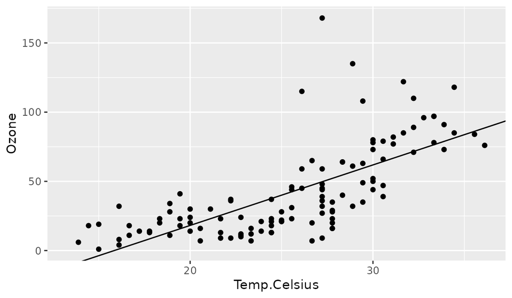

Figure 1: Linear model fit

### Change a param

Params are set with pipeflow’s `pip_set_params()`. pubflow checks the new value against the param’s rules before it is set:

```r
pip_set_params(pip, list(xVar = "Solar.R"))
pip_run(pip, lgr = NULL)
pip[["coef_table", "out"]]
```

Coefficients with 95% confidence limits

| Term | Estimate | Lower | Upper |
| --- | --- | --- | --- |
| (Intercept) | 18.599 | 5.225 | 31.973 |
| Solar.R | 0.127 | 0.062 | 0.192 |

An invalid value is an error, and nothing is set:

```r
pip_set_params(pip, list(xVar = "Height"))
# Error:
# ! Cannot set 2 parameters: nothing was set.
#   step 'fit', parameter 'xVar': value must be one of: Temp.Celsius, Wind, Solar.R
#   step 'plot', parameter 'xVar': value must be one of: Temp.Celsius, Wind, Solar.R
pip_set_params(pip, list(level = 1.5))
# Error:
# ! Cannot set 1 parameter: nothing was set.
#   step 'coef_table', parameter 'level': value must be less than or equal to max (0.999)
```

### A report file

`pub_render()` writes the document to a file with pandoc: a Word document, a PDF (via LaTeX or Typst) or Markdown. The metadata given at render time appear in the document, e.g. the author:

```r
file <- pub_render(doc, "docx", meta = list(author = "Jane Doe"))
basename(file)
# [1] "20261116T183223Z_ozone_in_new_york.docx"
```

By default, the file goes to R’s temporary directory, and its name is made of the render time and the title. Word and PDF need pandoc (>= 3.6); a PDF also needs a LaTeX installation (xelatex) or Typst (see the Reports vignette):

```r
pub_render(doc, "pdf", file = "ozone.pdf")
pub_render(doc, "pdf", file = "ozone.pdf", pdf_engine = "typst")
```

`pub_report_spec()` sets up the format of a report: page size and margins, a title page, a Word template, and more.

### A Shiny app

Two Shiny modules turn the pipeline into an app: `pub_params_ui()` with `pub_pipeline_params_server()` shows an input for every param of the pipeline and sets the values that the user enters in the pipeline, and `pub_viewer_ui()` with `pub_viewer_server()` shows the document.

```r
library(shiny)

ui <- fluidPage(
    fluidRow(
        column(4, pub_params_ui("params")),
        column(8, pub_viewer_ui("viewer", height = "90vh"))
    )
)

server <- function(input, output, session) {
    pip <- pip_clone(pip) # every session gets its own pipeline
    params <- pub_pipeline_params_server("params", pip)
    doc <- reactive({
        params$revision() # run again after every change of a param
        pip_run(pip, lgr = NULL)
        pip[["report", "out"]]
    })
    pub_viewer_server("viewer", doc)
}

shinyApp(ui, server)
```

An invalid input is marked and the last valid value is restored, so the pipeline only ever gets valid values. A pipeline is a reference object, so `server()` starts with a copy (`pip_clone()`): otherwise a change of a param in one session would also change the pipeline of every other session.

The report app that comes with pubflow shows more: grouped params, two reports from one pipeline, failed steps in the document and the download of the report. Run it with

```r
shiny::runApp(system.file("examples", "report-app", package = "pubflow"))
```

### Where next

The help pages of the functions used here describe them in detail:

- params: `?param`, `?param_config`, `?param_validity`, `?pub_get_params`;
- outputs: `?pub_table`, `?pub_figure`, `?pub_text`;
- documents: `?pub_doc`, `?pub_layout_inputs`;
- rendering and reports: `?pub_html`, `?pub_render`, `?pub_report_spec`;
- Shiny: `?pub_params_ui`, `?pub_viewer_ui`.